# Set up instructions

2021-04-20

Suggested length of workshop is **2 hours**.

## What might the attendee be able to do after being in your session?

In this workshop, attendees will learn how to use R to create, analyze, share, and publish the results of quality improvement (QI) projects based on tools published by the Institute for Healthcare Improvement and publishing recommendations from the Journal Of Graduate Medical Education.<sup>1</sup> This is a plug and play format that allows clinicians to directly create, analyze, and beautifully display their project and results with only a beginner’s knowledge of R, R Markdown, and spreadsheets.

## Description of the problem or gap

Many clinical informaticians participate in QI projects as either project leads or in supporting roles—helping other clinicians collect data from EHRs or implement projects within an EHR. There are many tools and guidelines for QI projects, but the tools are not well integrated into a single, comprehensive workflow of a QI project.

## Conclusion

At the end of the workshop, participants will have the knowledge and materials to create a QI project write-up and analysis all within a single R Markdown file. They will learn how to customize the project to suit many QI project proposals. This simplification of the QI project workflow will allow attendees to more quickly prepare QI project proposals and analyze their results. More advanced knowledge of R packages discussed at the workshop will allow users to create highly customized presentations of their work. A standardized tool to create QI projects will eliminate duplicated efforts in project workflows and allow results to be more quickly disseminated within an institution, posted online, or published in a journal.

## Attendee’s Take-away Tool

Attendee’s will be able to access the QI tools through a publicly available GitHub repository, which they will be able to download and modify for their own purposes. They will also receive a curated selection of advanced resources for further learning.

## Level of content

All content will be accessible to a beginner R user. However, each section of the **Play** part of the workshop will have intermediate and advanced topics embedded in the code for more advanced users to manipulate.

## Prerequisites

- Computer with internet connection
- Zoom
- Supported browser
- RStudio Cloud account—*free*
- Review preparatory materials to learn Markdown basics—*optional, but useful*

## Not required—but good for next steps after workshop

- Download R on personal computer
- RStudio IDE
- Github Account
- Know where to get help!

## Inspiration

From this paper<sup>1</sup>

## Outline of topics

**Systems check** *~15 minutes*

- Confirm accounts set up
- Discuss pre-workshop materials

**Introduction** *~30 minutes*

- R Markdown demo
- Knit a document
- View a demo GitHub Page

**Play** *~30 minutes*

**Wrap Up and Discussion** *~20 minutes*

- Discussion of participants questions
- Watch demonstration of publishing to Github Page
- Preview of advanced materials

## R Packages and Libraries

## Workshop Outline

## Markdown Basics

### rmarkdown Basics

## Citation Management

## Simulating Data in R

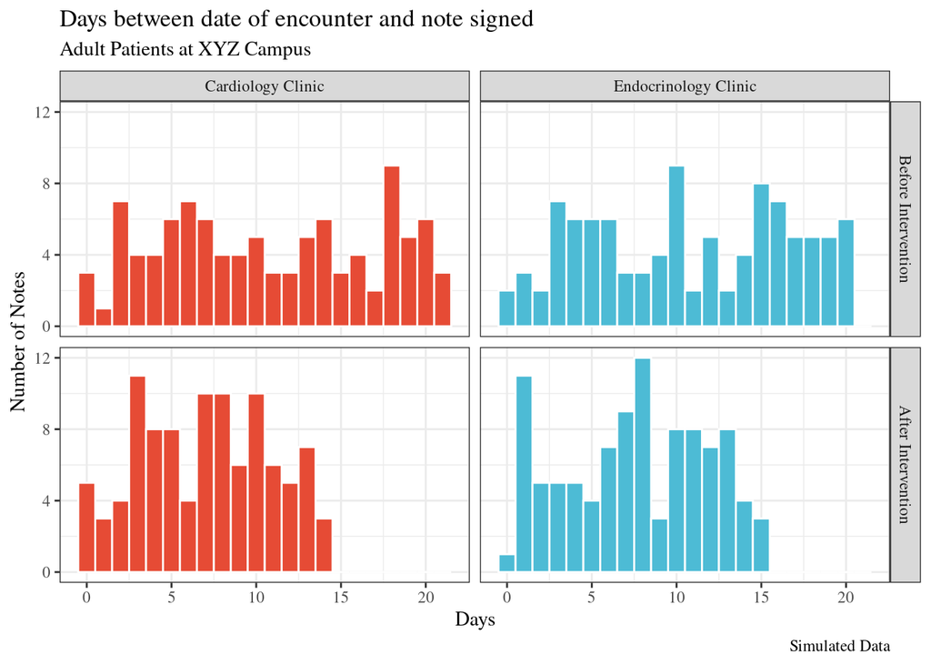

```r
pre_cards <- tibble(days = round(runif(100, 0, 21)), intervention = "Before Intervention", clinic = "Cardiology Clinic")
post_cards <- tibble(days = round(runif(100, 0, 14)), intervention = "After Intervention", clinic = "Cardiology Clinic")
pre_gi <- tibble(days = round(runif(100, 0, 20)), intervention = "Before Intervention", clinic = "Endocrinology Clinic")
post_gi <- tibble(days = round(runif(100, 0, 15)), intervention = "After Intervention", clinic = "Endocrinology Clinic")

data_histo <- bind_rows(pre_cards, post_cards, pre_gi, post_gi)

data_histo$intervention <- as_factor(data_histo$intervention)
data_histo$clinic <- as_factor(data_histo$clinic)



plot_data_histo <-  ggplot(data_histo, aes(days, fill = clinic)) +
  geom_histogram(binwidth = 1, color = 'white') +
  labs(title = "Days between date of encounter and note signed", subtitle = "Adult Patients at XYZ Campus", y = "Number of Notes", x = "Days", caption="Simulated Data") +
scale_y_continuous(breaks=c(0,4,8,12,16, 20, 24)) +
  facet_grid(intervention ~ clinic) +


  # To use for fills, add
  scale_color_npg(palette =     "nrc")+

# To use for line and point colors, add
  scale_fill_npg(palette =  "nrc") +

  theme_bw() +
  theme(legend.position = "none") +

  theme(text=element_text(family="serif"))

plot_data_histo
```

## Read Data in from Excel

### Scatter plot

```r
fake_data <- read_excel("./data/qi_spreadsheet_workshop.xlsx",
    sheet = "scatter")

scatter_plot <- ggplot(fake_data, aes(x = count, y = time, color = resident)) +
  geom_jitter() +
  labs(title = "Average Time from Admission Order to Order Reconciliation Completed", subtitle = "Academic Year 2012-2013 \nPGY-2 Residents", caption = "Simulated Data", x = "Number of Residents on Service", y = "Average Time (Mins)") +
  scale_x_continuous(breaks = (1:10)) +

  # To use for fills, add
  scale_color_jama()+

# To use for line and point colors, add
  scale_fill_lancet() +

  theme_bw() +

  scale_color_discrete(name="Service Type") +

  theme(legend.justification=c(1,0), legend.position=c(0.95,0.4), legend.box.background = element_rect(colour = "black")) +

  theme(text=element_text(family="serif"))
```

[output not shown]

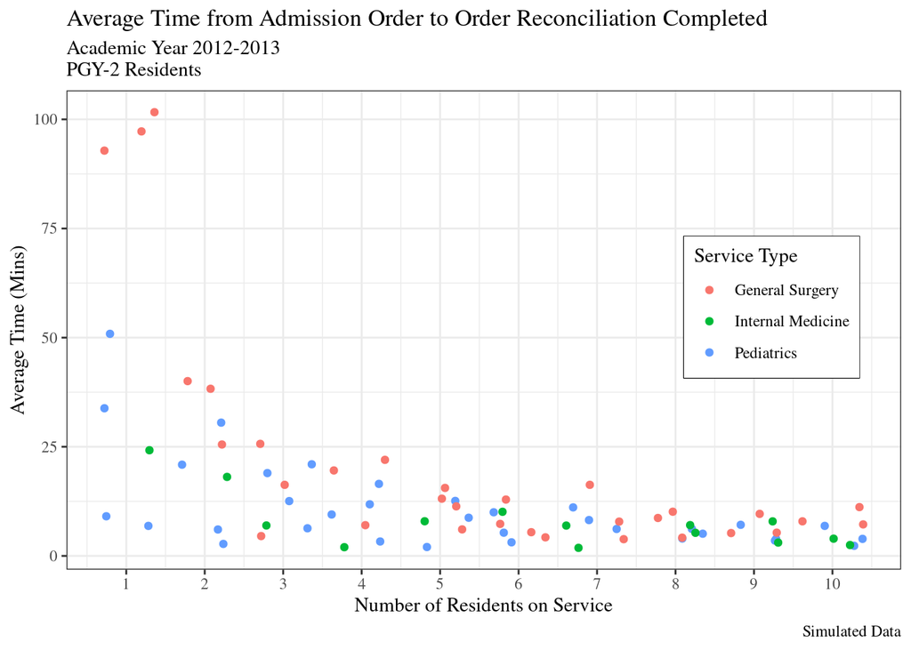

```r
scatter_plot
```

### Pareto Chart

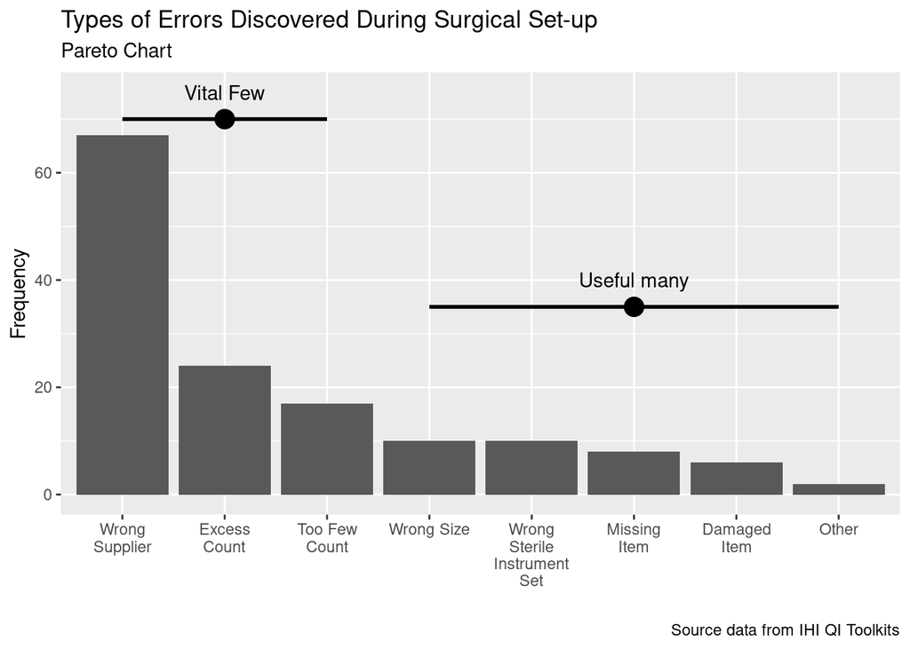

```r
pareto <- read_excel("./data/qi_spreadsheet_workshop.xlsx",
    sheet = "Pareto")

plot_pareto <- ggplot(pareto, aes(x = reorder(`Error Type`, -`Frequency`), y = `Frequency`)) +
  geom_col() +
  labs(title = "Types of Errors Discovered During Surgical Set-up", subtitle = "Pareto Chart", x = " ", y = "Frequency", caption = "Source data from IHI QI Toolkits") +
  #theme(axis.text.x = element_text(angle = 45)) +
  scale_x_discrete(labels = function(x) str_wrap(x, width = 10)) +
  annotate("text", x = 2, y = 75, label = "Vital Few") +
  annotate("pointrange", x= 2, y = 70, xmin = 1, xmax = 3,
  colour = "black", size = 1) +
  annotate("text", x = 6, y = 40, label = "Useful many") +
  annotate("pointrange", x= 6, y = 35, xmin = 4, xmax = 8,
  colour = "black", size = 1)


plot_pareto
```

## References

1. Wong BM, Sullivan GM. How to Write Up Your Quality Improvement Initiatives for Publication [Internet]. Journal of Graduate Medical Education. 2016 May ;8(2):128–133.[cited 2021 Jan. 12] Available from: https://www.ncbi.nlm.nih.gov/pmc/articles/PMC4857497/